# spotify_strava_v3

### Cross-Platform Temporal Analysis: Spotify × Strava

**Author:** Andrew Bonnah  
**Last updated:** 2026  
**Tools:** Python · pandas · scipy · matplotlib · seaborn

Spotify and Strava have no shared schema — no common IDs, no linked accounts. The only thread connecting a song to a run is **time**. This notebook builds a temporal join from scratch, constructs performance features at the run and artist level, and runs a proper statistical validation to ask whether my listening habits have any measurable relationship with how I perform.

Three performance dimensions are examined: **pace** (avg speed), **volume** (distance), and **terrain** (total elevation gain). Elevation is a particularly interesting target because it's largely determined by route choice before a run starts — making it a plausible proxy for *intent*, and a realistic confounder for any speed or artist-level finding.

> **Honest framing:** This is correlational, not causal. Music choices reflect intent — I reach for harder tracks on days I plan to push. Any association between artist and pace (or elevation) is as likely to capture that selection effect as any direct physiological impact. The goal is to build the right infrastructure and see if signal even exists.
1. Imports & Configuration
2. Data Loading & Cleaning
3. Temporal Join: Linking Songs to Runs
4. Feature Engineering
5. Exploratory Data Analysis
   - 5.1 Running baseline distributions (speed, distance, elevation)
   - 5.2 Temporal patterns (when I run)
   - 5.3 Listening behavior during runs
   - 5.4 Artist associations with speed, distance & elevation
   - 5.5 Most frequent artists
   - 5.6 Music data coverage check
6. Statistical Validation
   - 6.1 Correlation matrix (now includes elevation)
   - 6.2 Welch's t-test: top artists vs rest
   - 6.3 Effect size: Cohen's d
   - 6.4 Time-of-day confounder (ANOVA)
7. Elevation Deep-Dive
8. Confounder Analysis
9. Key Findings
10. Limitations
11. What's Next

## 1. Imports & Configuration

```python
import pandas as pd
import numpy as np
import json
import matplotlib.pyplot as plt
import matplotlib.gridspec as gridspec
import matplotlib.patches as mpatches
import seaborn as sns
from datetime import timedelta
from scipy import stats

# ── Plot style ──────────────────────────────────────────────────────────────
PALETTE = {
    'primary':   '#1DB954',   # Spotify green
    'secondary': '#E8450A',   # warm orange
    'accent':    '#3D7FBF',   # steel blue
    'neutral':   '#888888',
    'bg':        '#F9F9F8',
}

plt.rcParams.update({
    'figure.dpi':          130,
    'figure.facecolor':    PALETTE['bg'],
    'axes.facecolor':      PALETTE['bg'],
    'axes.spines.top':     False,
    'axes.spines.right':   False,
    'axes.spines.left':    False,
    'axes.spines.bottom':  False,
    'axes.grid':           True,
    'grid.alpha':          0.25,
    'grid.linestyle':      '--',
    'font.family':         'sans-serif',
    'font.size':           11,
    'axes.titlesize':      13,
    'axes.titleweight':    'semibold',
    'axes.labelcolor':     '#444',
    'xtick.color':         '#666',
    'ytick.color':         '#666',
})

def style_ax(ax, title=None, xlabel=None, ylabel=None):
    """Apply consistent finishing touches to an axes."""
    if title:   ax.set_title(title, pad=10)
    if xlabel:  ax.set_xlabel(xlabel, labelpad=8)
    if ylabel:  ax.set_ylabel(ylabel, labelpad=8)
    ax.tick_params(length=0)
    return ax

def safe_label(name):
    """Escape $ signs so matplotlib doesn't treat them as LaTeX math delimiters."""
    return str(name).replace('$', r'\$')

print('Libraries loaded.')
```

```
Libraries loaded.
```

## 2. Data Loading & Cleaning

Both datasets come from personal data export requests — no API, no scraping.

| Dataset | Export format | Key constraint |
| --- | --- | --- |
| Strava activities | CSV | One row per activity; includes all sport types |
| Spotify streaming history | JSON | ~12 months max; only `endTime` provided (no start) |

### 2.1 Strava

```python
strava_df = pd.read_csv('strava_activities.csv')
print(f'Raw shape: {strava_df.shape}')

# Drop administrative/social columns that add no analytical value
drop_cols = [
    'resource_state', 'athlete', 'comment_count', 'photo_count', 'total_photo_count',
    'athlete_count', 'kudos_count', 'has_kudoed', 'pr_count', 'trainer', 'commute',
    'manual', 'private', 'visibility', 'flagged', 'from_accepted_tag',
    'display_hide_heartrate_option', 'heartrate_opt_out', 'upload_id',
    'upload_id_str', 'external_id', 'gear_id', 'location_city', 'location_state',
    'location_country', 'workout_type', 'type', 'sport_type', 'device_name', 'has_heartrate'
]
strava_df = strava_df.drop(columns=[c for c in drop_cols if c in strava_df.columns])

# Parse timestamps; derive end time from elapsed seconds
strava_df['start_date'] = pd.to_datetime(strava_df['start_date'])
strava_df['end_date']   = strava_df['start_date'] + pd.to_timedelta(strava_df['elapsed_time'], unit='s')

# Unit conversions to imperial
strava_df['avg_speed_mph']    = strava_df['average_speed'] * 2.23694
strava_df['distance_miles']   = strava_df['distance']      * 0.000621371
strava_df['elapsed_minutes']  = strava_df['elapsed_time']  / 60

# Elevation — Strava exports in meters, convert to feet
# total_elevation_gain: cumulative ascent over the run (descents not counted)
if 'total_elevation_gain' in strava_df.columns:
    strava_df['elevation_gain_ft'] = strava_df['total_elevation_gain'] * 3.28084
    # Elevation gain per mile — controls for the fact that longer runs naturally gain more
    strava_df['elev_gain_per_mile'] = (
        strava_df['elevation_gain_ft'] / strava_df['distance_miles'].replace(0, np.nan)
    )
    print(f'Elevation data present: {strava_df["elevation_gain_ft"].notna().sum()} runs with values')
    print(f'  Mean elevation gain: {strava_df["elevation_gain_ft"].mean():.0f} ft')
    print(f'  Max elevation gain:  {strava_df["elevation_gain_ft"].max():.0f} ft')
else:
    print('⚠  total_elevation_gain column not found — elevation analysis will be skipped')
    strava_df['elevation_gain_ft'] = np.nan
    strava_df['elev_gain_per_mile'] = np.nan

# Time features for confounder analysis
strava_df['hour_of_day'] = strava_df['start_date'].dt.hour
strava_df['day_of_week'] = strava_df['start_date'].dt.day_name()
strava_df['month']       = strava_df['start_date'].dt.to_period('M').astype(str)
strava_df['week']        = strava_df['start_date'].dt.isocalendar().week

print(f'\nCleaned shape: {strava_df.shape}')
strava_df[['start_date', 'end_date', 'avg_speed_mph', 'distance_miles',
           'elapsed_minutes', 'elevation_gain_ft']].head()
```

```
Raw shape: (73, 48)
Elevation data present: 73 runs with values
  Mean elevation gain: 139 ft
  Max elevation gain:  455 ft

Cleaned shape: (73, 28)
```

|  | start_date | end_date | avg_speed_mph | distance_miles | elapsed_minutes | elevation_gain_ft |
| --- | --- | --- | --- | --- | --- | --- |
| 0 | 2026-04-24 18:58:53+00:00 | 2026-04-24 19:58:09+00:00 | 6.625816 | 6.317479 | 59.266667 | 232.611556 |
| 1 | 2026-04-22 17:02:02+00:00 | 2026-04-22 17:59:06+00:00 | 6.549760 | 6.120132 | 57.066667 | 238.845152 |
| 2 | 2026-04-21 19:04:13+00:00 | 2026-04-21 19:28:09+00:00 | 7.296898 | 2.898261 | 23.933333 | 79.068244 |
| 3 | 2026-04-20 18:35:37+00:00 | 2026-04-20 19:26:29+00:00 | 6.388701 | 5.394619 | 50.866667 | 181.102368 |
| 4 | 2026-04-19 17:12:34+00:00 | 2026-04-19 18:06:12+00:00 | 5.822755 | 4.733480 | 53.633333 | 149.278220 |

### 2.2 Spotify

```python
spotify_df = pd.read_json('Spotify_Account_Data/StreamingHistory_music_0.json')
print(f'Raw shape: {spotify_df.shape}')

# Normalize timestamps and derive startTime
# Spotify only gives endTime — we back-calculate from msPlayed
spotify_df['endTime']      = pd.to_datetime(spotify_df['endTime']).dt.tz_localize(None)
spotify_df['startTime']    = spotify_df['endTime'] - pd.to_timedelta(spotify_df['msPlayed'], unit='ms')
spotify_df['duration_sec'] = spotify_df['msPlayed'] / 1000

# Filter out skipped tracks (played < 10s — probably accidental)
before = len(spotify_df)
spotify_df = spotify_df[spotify_df['duration_sec'] >= 10].copy()
print(f'Dropped {before - len(spotify_df)} skipped/accidental plays (<10s)')

print(f'\nDate range: {spotify_df["endTime"].min().date()}  →  {spotify_df["endTime"].max().date()}')
print(f'Unique artists: {spotify_df["artistName"].nunique():,}')
print(f'Unique tracks:  {spotify_df["trackName"].nunique():,}')
spotify_df.head(3)
```

```
Raw shape: (8076, 4)
Dropped 846 skipped/accidental plays (<10s)

Date range: 2025-04-29  →  2026-04-28
Unique artists: 1,397
Unique tracks:  3,764
```

|  | endTime | artistName | trackName | msPlayed | startTime | duration_sec |
| --- | --- | --- | --- | --- | --- | --- |
| 0 | 2025-04-29 21:22:00 | Mick Jenkins | Jazz | 231751 | 2025-04-29 21:18:08.249 | 231.751 |
| 3 | 2025-04-29 22:09:00 | Yellowman | Zungguzungguguzungguzeng | 24796 | 2025-04-29 22:08:35.204 | 24.796 |
| 5 | 2025-04-30 01:23:00 | The Smashing Pumpkins | Zero - Remastered 2012 | 160173 | 2025-04-30 01:20:19.827 | 160.173 |

## 3. Temporal Join: Linking Songs to Runs

This is the core engineering challenge. With no shared key, the join has to be built on time alone.

**Logic:** For each run, scan every Spotify play event and keep tracks where **more than 50% of the song's duration fell inside the run window**.

The 50% threshold is a deliberate design call:

- Too low (e.g. 10%) → includes songs that barely overlapped at the edges
- Too high (e.g. 90%) → misses songs that started just before the run or finished just after
- 50% is a reasonable "actually listened to this during the run" bar

> This threshold is a parameter, not a truth. Different values produce different join results and different downstream conclusions.

```python
def song_in_run(row, run_start, run_end):
    """
    Returns True if >50% of this track's play duration overlapped
    with the run window [run_start, run_end].
    """
    overlap_start = max(row['startTime'], run_start)
    overlap_end   = min(row['endTime'],   run_end)
    overlap_sec   = (overlap_end - overlap_start).total_seconds()
    song_dur_sec  = row['duration_sec']

    if song_dur_sec <= 0:
        return False
    return overlap_sec > 0.5 * song_dur_sec


# Strip timezone info from Strava so comparisons work cleanly
strava_naive = strava_df.copy()
strava_naive['start_date'] = strava_naive['start_date'].dt.tz_localize(None)
strava_naive['end_date']   = strava_naive['end_date'].dt.tz_localize(None)

run_songs_dict = {}
for _, run in strava_naive.iterrows():
    mask = spotify_df.apply(
        song_in_run, axis=1,
        run_start=run['start_date'],
        run_end=run['end_date']
    )
    run_songs_dict[run['id']] = spotify_df[mask].index.tolist()

matched   = sum(1 for v in run_songs_dict.values() if len(v) > 0)
unmatched = len(strava_df) - matched
match_rate = matched / len(strava_df)

print(f'Total runs:           {len(strava_df):>5}')
print(f'Runs with music data: {matched:>5}  ({match_rate:.1%})')
print(f'Runs without match:   {unmatched:>5}  (predates Spotify export window)')
```

```
Total runs:              73
Runs with music data:    40  (54.8%)
Runs without match:      33  (predates Spotify export window)
```

### 3.1 Data Coverage: Where Does the Overlap Actually Fall?

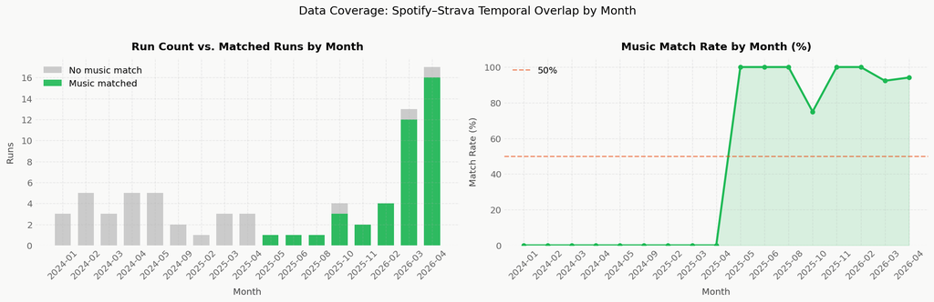

```
Coverage note: months with <50% match rate are outside the Spotify export window.
```

```python
# Build monthly coverage summary
run_match_summary = [
    {
        'run_id':     run['id'],
        'start_date': run['start_date'],
        'month':      run['month'],
        'n_songs':    len(run_songs_dict.get(run['id'], [])),
        'has_music':  len(run_songs_dict.get(run['id'], [])) > 0
    }
    for _, run in strava_df.iterrows()
]
match_df = pd.DataFrame(run_match_summary)
match_df['start_date'] = pd.to_datetime(match_df['start_date'])

monthly = match_df.copy()
monthly['ym'] = monthly['start_date'].dt.to_period('M')
monthly_agg = monthly.groupby('ym').agg(
    total_runs   =('run_id',    'count'),
    matched_runs =('has_music', 'sum')
).reset_index()
monthly_agg['match_rate'] = monthly_agg['matched_runs'] / monthly_agg['total_runs']
monthly_agg['ym_str']     = monthly_agg['ym'].astype(str)

fig, axes = plt.subplots(1, 2, figsize=(16, 5), facecolor=PALETTE['bg'])
fig.suptitle('Data Coverage: Spotify–Strava Temporal Overlap by Month', fontsize=14, y=1.02)

# Stacked bar
axes[0].bar(monthly_agg['ym_str'], monthly_agg['total_runs'],
            color=PALETTE['neutral'], alpha=0.4, label='No music match', width=0.7)
axes[0].bar(monthly_agg['ym_str'], monthly_agg['matched_runs'],
            color=PALETTE['primary'], alpha=0.9, label='Music matched', width=0.7)
style_ax(axes[0], 'Run Count vs. Matched Runs by Month', 'Month', 'Runs')
axes[0].tick_params(axis='x', rotation=45)
axes[0].legend(frameon=False)

# Match rate line
axes[1].fill_between(monthly_agg['ym_str'], monthly_agg['match_rate'] * 100,
                     alpha=0.15, color=PALETTE['primary'])
axes[1].plot(monthly_agg['ym_str'], monthly_agg['match_rate'] * 100,
             color=PALETTE['primary'], marker='o', linewidth=2.5, markersize=5)
axes[1].axhline(50, color=PALETTE['secondary'], linestyle='--', alpha=0.6, label='50%')
style_ax(axes[1], 'Music Match Rate by Month (%)', 'Month', 'Match Rate (%)')
axes[1].tick_params(axis='x', rotation=45)
axes[1].set_ylim(0, 105)
axes[1].legend(frameon=False)

plt.tight_layout()
plt.show()
print(f'Coverage note: months with <50% match rate are outside the Spotify export window.')
```

## 4. Feature Engineering

With the join built, I construct features at two levels:

**Run level** — characterizes the listening experience per run  
**Artist level** — aggregates performance metrics across all runs an artist appeared in

Three performance targets are tracked per artist:

- `avg_speed` — mean pace across matched runs
- `avg_distance` — mean distance
- `avg_elevation` — mean total elevation gain (ft); tells us whether an artist tends to appear on hilly vs flat routes

Artists who only appeared in a single run are excluded from artist-level comparisons — a one-run average has no variance and no interpretive value.

```python
# ── Flatten run_songs_dict into a long-form dataframe ──────────────────────
rows = []
for run_id, song_idxs in run_songs_dict.items():
    for idx in song_idxs:
        song = spotify_df.loc[idx]
        rows.append({
            'run_id':       run_id,
            'artistName':   song['artistName'],
            'trackName':    song['trackName'],
            'duration_sec': song['duration_sec'],
        })

run_song_flat = pd.DataFrame(rows)
print(f'Total run–song pairs: {len(run_song_flat):,}')

# ── Merge with run-level performance metrics ────────────────────────────────
run_meta = strava_df[['id', 'avg_speed_mph', 'distance_miles', 'elapsed_minutes',
                       'elevation_gain_ft', 'elev_gain_per_mile',
                       'hour_of_day', 'day_of_week', 'month', 'start_date']].copy()
run_song_flat = run_song_flat.merge(run_meta, left_on='run_id', right_on='id', how='left')

# ── Run-level listening features ────────────────────────────────────────────
run_level = run_song_flat.groupby('run_id').agg(
    n_songs           =('trackName',    'count'),
    n_unique_artists  =('artistName',   'nunique'),
    n_unique_tracks   =('trackName',    'nunique'),
    total_music_sec   =('duration_sec', 'sum'),
).reset_index()
run_level = run_level.merge(run_meta, left_on='run_id', right_on='id', how='left')
run_level['songs_per_minute']  = run_level['n_songs'] / run_level['elapsed_minutes']
run_level['track_repeat_rate'] = 1 - (run_level['n_unique_tracks'] / run_level['n_songs'])

# ── Artist-level aggregate features ────────────────────────────────────────
artist_summary = run_song_flat.groupby('artistName').agg(
    avg_speed        =('avg_speed_mph',      'mean'),
    std_speed        =('avg_speed_mph',      'std'),
    median_speed     =('avg_speed_mph',      'median'),
    avg_distance     =('distance_miles',     'mean'),
    std_distance     =('distance_miles',     'std'),
    avg_elevation    =('elevation_gain_ft',  'mean'),
    std_elevation    =('elevation_gain_ft',  'std'),
    avg_elev_per_mi  =('elev_gain_per_mile', 'mean'),
    appearance_count =('run_id',             'nunique'),
    total_plays      =('trackName',          'count'),
).reset_index()

# Filter to artists with 2+ run appearances
artist_summary_filtered = artist_summary[artist_summary['appearance_count'] >= 2].copy()

print(f'Artists with 2+ appearances: {len(artist_summary_filtered)}')
print(f'Filtered out:                {len(artist_summary) - len(artist_summary_filtered)} single-run artists')
print()
print('Top 8 by avg elevation gain (ft):')
print(
    artist_summary_filtered
    .sort_values('avg_elevation', ascending=False)
    .head(8)[['artistName', 'avg_elevation', 'std_elevation', 'avg_speed', 'appearance_count']]
    .to_string(index=False)
)
```

```
Total run–song pairs: 530
Artists with 2+ appearances: 85
Filtered out:                96 single-run artists

Top 8 by avg elevation gain (ft):
    artistName  avg_elevation  std_elevation  avg_speed  appearance_count
     prod. DTM     241.797908       4.175828   6.470349                 2
Dillon Francis     237.532816       4.651393   6.530970                 3
       DECiBEL     237.204732       6.495732   6.526272                 2
 Bert On Beats     237.204732       5.303743   6.526272                 2
         Diplo     237.204732       6.495732   6.526272                 2
    DJ Ketchup     237.204732       6.495732   6.526272                 2
  DJ Du Marcel     237.204732       6.495732   6.526272                 2
     Costuleta     237.204732       6.495732   6.526272                 2
```

## 5. Exploratory Data Analysis

### 5.1 Running Baseline — What Do My Runs Actually Look Like?

Before slicing by artist, I need to understand the baseline distributions of my core performance variables: **speed**, **distance**, **duration**, and **elevation gain**.

Elevation is worth paying particular attention to. If my runs vary wildly in hilliness, then any speed difference between groups might just be topography — faster on flat days, slower on hilly ones. The elevation distribution tells me how much of that variance is in play.

```
Speed ~ Elevation: r = 0.056, p = 0.6353
  → Weak correlation: elevation and speed largely independent in this dataset.
```

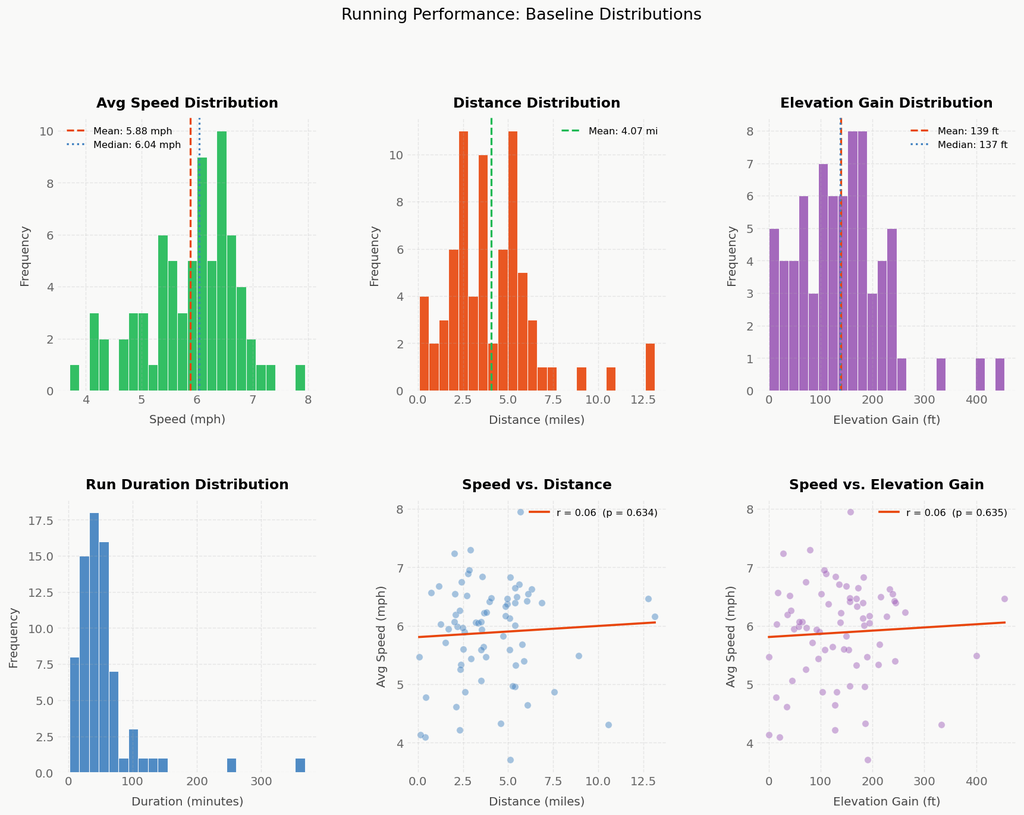

```
       avg_speed_mph  distance_miles  elapsed_minutes  elevation_gain_ft
count          73.00           73.00            73.00              73.00
mean            5.88            4.07            53.89             139.19
std             0.84            2.50            52.66              87.04
min             3.70            0.07             1.57               0.00
25%             5.44            2.38            28.07              72.51
50%             6.04            3.65            45.37             137.47
75%             6.47            5.39            59.27             184.71
max             7.95           13.14           368.42             454.72
```

```python
fig = plt.figure(figsize=(16, 11), facecolor=PALETTE['bg'])
fig.suptitle('Running Performance: Baseline Distributions', fontsize=15, y=1.01)
gs = fig.add_gridspec(2, 3, hspace=0.4, wspace=0.35)

ax_speed = fig.add_subplot(gs[0, 0])
ax_dist  = fig.add_subplot(gs[0, 1])
ax_elev  = fig.add_subplot(gs[0, 2])
ax_dur   = fig.add_subplot(gs[1, 0])
ax_scat  = fig.add_subplot(gs[1, 1])
ax_escat = fig.add_subplot(gs[1, 2])

# Speed
ax_speed.hist(strava_df['avg_speed_mph'].dropna(), bins=24,
              color=PALETTE['primary'], edgecolor='white', linewidth=0.6, alpha=0.9)
ax_speed.axvline(strava_df['avg_speed_mph'].mean(), color=PALETTE['secondary'],
                 linestyle='--', linewidth=1.8,
                 label=f'Mean: {strava_df["avg_speed_mph"].mean():.2f} mph')
ax_speed.axvline(strava_df['avg_speed_mph'].median(), color=PALETTE['accent'],
                 linestyle=':', linewidth=1.8,
                 label=f'Median: {strava_df["avg_speed_mph"].median():.2f} mph')
ax_speed.legend(frameon=False, fontsize=9)
style_ax(ax_speed, 'Avg Speed Distribution', 'Speed (mph)', 'Frequency')

# Distance
ax_dist.hist(strava_df['distance_miles'].dropna(), bins=24,
             color=PALETTE['secondary'], edgecolor='white', linewidth=0.6, alpha=0.9)
ax_dist.axvline(strava_df['distance_miles'].mean(), color=PALETTE['primary'],
                linestyle='--', linewidth=1.8,
                label=f'Mean: {strava_df["distance_miles"].mean():.2f} mi')
ax_dist.legend(frameon=False, fontsize=9)
style_ax(ax_dist, 'Distance Distribution', 'Distance (miles)', 'Frequency')

# Elevation
elev_data = strava_df['elevation_gain_ft'].dropna()
if len(elev_data) > 0:
    ax_elev.hist(elev_data, bins=24,
                 color='#9B59B6', edgecolor='white', linewidth=0.6, alpha=0.9)
    ax_elev.axvline(elev_data.mean(), color=PALETTE['secondary'], linestyle='--', linewidth=1.8,
                    label=f'Mean: {elev_data.mean():.0f} ft')
    ax_elev.axvline(elev_data.median(), color=PALETTE['accent'], linestyle=':', linewidth=1.8,
                    label=f'Median: {elev_data.median():.0f} ft')
    ax_elev.legend(frameon=False, fontsize=9)
else:
    ax_elev.text(0.5, 0.5, 'No elevation data', ha='center', va='center', transform=ax_elev.transAxes)
style_ax(ax_elev, 'Elevation Gain Distribution', 'Elevation Gain (ft)', 'Frequency')

# Duration
ax_dur.hist(strava_df['elapsed_minutes'].dropna(), bins=24,
            color=PALETTE['accent'], edgecolor='white', linewidth=0.6, alpha=0.9)
style_ax(ax_dur, 'Run Duration Distribution', 'Duration (minutes)', 'Frequency')

# Speed vs Distance
sdf = strava_df[['distance_miles', 'avg_speed_mph']].dropna()
ax_scat.scatter(sdf['distance_miles'], sdf['avg_speed_mph'],
                alpha=0.45, color=PALETTE['accent'], edgecolors='white', linewidth=0.4, s=40)
m, b, r, p, _ = stats.linregress(sdf['distance_miles'], sdf['avg_speed_mph'])
x_line = np.linspace(sdf['distance_miles'].min(), sdf['distance_miles'].max(), 100)
ax_scat.plot(x_line, m*x_line+b, color=PALETTE['secondary'], linewidth=2,
             label=f'r = {r:.2f}  (p = {p:.3f})')
ax_scat.legend(frameon=False, fontsize=9)
style_ax(ax_scat, 'Speed vs. Distance', 'Distance (miles)', 'Avg Speed (mph)')

# Speed vs Elevation — the key new chart
edf = strava_df[['elevation_gain_ft', 'avg_speed_mph']].dropna()
if len(edf) > 5:
    sc = ax_escat.scatter(edf['elevation_gain_ft'], edf['avg_speed_mph'],
                          alpha=0.45, color='#9B59B6', edgecolors='white', linewidth=0.4, s=40)
    m2, b2, r2, p2, _ = stats.linregress(edf['elevation_gain_ft'], edf['avg_speed_mph'])
    x2 = np.linspace(edf['elevation_gain_ft'].min(), edf['elevation_gain_ft'].max(), 100)
    ax_escat.plot(x2, m2*x2+b2, color=PALETTE['secondary'], linewidth=2,
                  label=f'r = {r2:.2f}  (p = {p2:.3f})')
    ax_escat.legend(frameon=False, fontsize=9)
    print(f'Speed ~ Elevation: r = {r2:.3f}, p = {p2:.4f}')
    if r2 < -0.15:
        print('  → Negative correlation: hillier runs tend to be slower (expected).')
    elif abs(r2) < 0.1:
        print('  → Weak correlation: elevation and speed largely independent in this dataset.')
style_ax(ax_escat, 'Speed vs. Elevation Gain', 'Elevation Gain (ft)', 'Avg Speed (mph)')

plt.tight_layout()
plt.show()

print()
print(strava_df[['avg_speed_mph', 'distance_miles', 'elapsed_minutes', 'elevation_gain_ft']].describe().round(2))
```

### 5.2 Temporal Patterns — When Do I Run?

If I systematically do my hilly runs on weekends and my flat runs on weekdays, then any artist who appears frequently on Saturdays will look "hilly" even if the terrain is doing all the work. This chart is the first step in untangling that.

```
Hilliest day on average:  Saturday  (190 ft)
Flattest day on average:  Tuesday  (115 ft)
Fastest day on average:   Wednesday  (6.25 mph)
  → Fastest and hilliest days differ — terrain and pace vary somewhat independently by day.
```

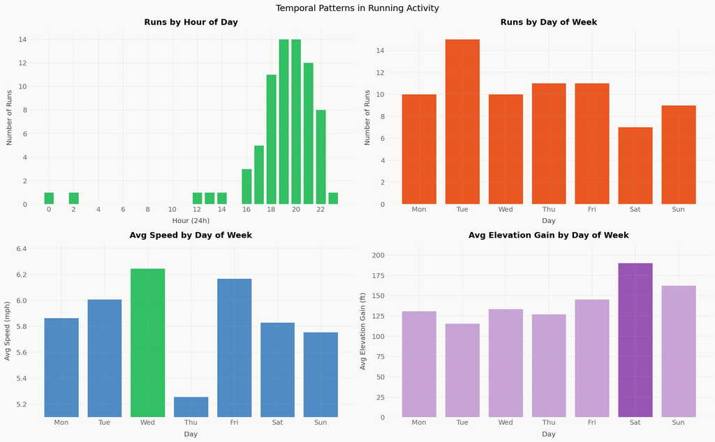

```python
fig, axes = plt.subplots(2, 2, figsize=(16, 10), facecolor=PALETTE['bg'])
fig.suptitle('Temporal Patterns in Running Activity', fontsize=14)

day_order = ['Monday', 'Tuesday', 'Wednesday', 'Thursday', 'Friday', 'Saturday', 'Sunday']

# Hour of day
hour_counts = strava_df['hour_of_day'].value_counts().sort_index()
axes[0,0].bar(hour_counts.index, hour_counts.values,
              color=PALETTE['primary'], edgecolor='white', linewidth=0.5, alpha=0.9, width=0.8)
axes[0,0].set_xticks(range(0, 24, 2))
style_ax(axes[0,0], 'Runs by Hour of Day', 'Hour (24h)', 'Number of Runs')

# Day of week count
dow_counts = strava_df['day_of_week'].value_counts().reindex(day_order).fillna(0)
axes[0,1].bar(range(7), dow_counts.values,
              color=PALETTE['secondary'], edgecolor='white', linewidth=0.5, alpha=0.9)
axes[0,1].set_xticks(range(7))
axes[0,1].set_xticklabels([d[:3] for d in day_order])
style_ax(axes[0,1], 'Runs by Day of Week', 'Day', 'Number of Runs')

# Avg speed by day
speed_by_day = strava_df.groupby('day_of_week')['avg_speed_mph'].mean().reindex(day_order)
colors_spd = [PALETTE['primary'] if v == speed_by_day.max() else PALETTE['accent']
              for v in speed_by_day.values]
axes[1,0].bar(range(7), speed_by_day.values,
              color=colors_spd, edgecolor='white', linewidth=0.5, alpha=0.9)
axes[1,0].set_xticks(range(7))
axes[1,0].set_xticklabels([d[:3] for d in day_order])
axes[1,0].set_ylim(speed_by_day.min() * 0.97, speed_by_day.max() * 1.03)
style_ax(axes[1,0], 'Avg Speed by Day of Week', 'Day', 'Avg Speed (mph)')

# ── NEW: Avg elevation by day ───────────────────────────────────────────────
elev_by_day = strava_df.groupby('day_of_week')['elevation_gain_ft'].mean().reindex(day_order)
elev_valid  = elev_by_day.dropna()
if len(elev_valid) > 0:
    colors_elv = ['#8E44AD' if v == elev_valid.max() else '#C39BD3'
                  for v in elev_by_day.values]
    axes[1,1].bar(range(7), elev_by_day.fillna(0).values,
                  color=colors_elv, edgecolor='white', linewidth=0.5, alpha=0.9)
    axes[1,1].set_xticks(range(7))
    axes[1,1].set_xticklabels([d[:3] for d in day_order])
    axes[1,1].set_ylim(0, elev_valid.max() * 1.12)
    style_ax(axes[1,1], 'Avg Elevation Gain by Day of Week', 'Day', 'Avg Elevation Gain (ft)')

    hilliest_day  = elev_by_day.idxmax()
    flattest_day  = elev_by_day.idxmin()
    fastest_day   = speed_by_day.idxmax()
    print(f'Hilliest day on average:  {hilliest_day}  ({elev_by_day.max():.0f} ft)')
    print(f'Flattest day on average:  {flattest_day}  ({elev_by_day.min():.0f} ft)')
    print(f'Fastest day on average:   {fastest_day}  ({speed_by_day.max():.2f} mph)')
    if hilliest_day == fastest_day:
        print('  ⚠ Hilliest and fastest day overlap — elevation may not be suppressing speed here.')
    elif flattest_day == fastest_day:
        print('  → Fastest day is also flattest — terrain likely contributes to the speed signal.')
    else:
        print('  → Fastest and hilliest days differ — terrain and pace vary somewhat independently by day.')
else:
    axes[1,1].text(0.5, 0.5, 'No elevation data', ha='center', va='center',
                   transform=axes[1,1].transAxes, color=PALETTE['neutral'])
    style_ax(axes[1,1], 'Avg Elevation Gain by Day of Week')

plt.tight_layout()
plt.show()
```

### 5.3 Listening Behavior During Runs

```
Songs per run ~ Elevation: r = 0.608,  p = 0.0000
  → More songs on hillier runs — likely because hilly runs are longer.
```

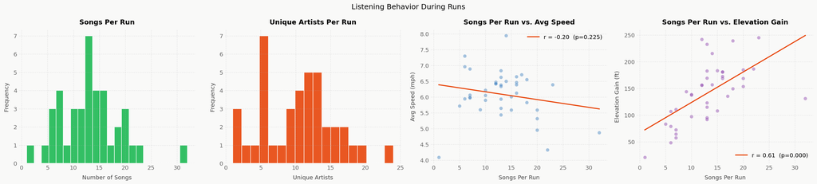

```
       n_songs  n_unique_artists  songs_per_minute  track_repeat_rate
count   40.000            40.000            40.000             40.000
mean    13.250            10.400             0.297              0.009
std      5.869             5.324             0.047              0.029
min      1.000             1.000             0.132              0.000
25%      9.750             6.000             0.276              0.000
50%     13.000            10.500             0.308              0.000
75%     16.000            13.000             0.325              0.000
max     32.000            24.000             0.378              0.143
```

```python
# Join elevation into run_level for this section
run_level_plot = run_level.copy()
if 'elevation_gain_ft' not in run_level_plot.columns:
    run_level_plot = run_level_plot.merge(
        strava_df[['id','elevation_gain_ft']], left_on='run_id', right_on='id', how='left'
    )

fig, axes = plt.subplots(1, 4, figsize=(22, 5), facecolor=PALETTE['bg'])
fig.suptitle('Listening Behavior During Runs', fontsize=14)

# Songs per run
axes[0].hist(run_level_plot['n_songs'].dropna(), bins=22,
             color=PALETTE['primary'], edgecolor='white', alpha=0.9)
style_ax(axes[0], 'Songs Per Run', 'Number of Songs', 'Frequency')

# Unique artists per run
axes[1].hist(run_level_plot['n_unique_artists'].dropna(), bins=18,
             color=PALETTE['secondary'], edgecolor='white', alpha=0.9)
style_ax(axes[1], 'Unique Artists Per Run', 'Unique Artists', 'Frequency')

# Songs vs speed
rl_spd = run_level_plot.dropna(subset=['n_songs', 'avg_speed_mph'])
axes[2].scatter(rl_spd['n_songs'], rl_spd['avg_speed_mph'],
                alpha=0.45, color=PALETTE['accent'], edgecolors='white', linewidth=0.4, s=45)
if len(rl_spd) > 5:
    m_s, b_s, r_s, p_s, _ = stats.linregress(rl_spd['n_songs'], rl_spd['avg_speed_mph'])
    x_s = np.linspace(rl_spd['n_songs'].min(), rl_spd['n_songs'].max(), 100)
    axes[2].plot(x_s, m_s*x_s+b_s, color=PALETTE['secondary'],
                 linewidth=2, label=f'r = {r_s:.2f}  (p={p_s:.3f})')
    axes[2].legend(frameon=False)
style_ax(axes[2], 'Songs Per Run vs. Avg Speed', 'Songs Per Run', 'Avg Speed (mph)')

# ── NEW: Songs vs elevation ──────────────────────────────────────────────────
rl_elv = run_level_plot.dropna(subset=['n_songs', 'elevation_gain_ft'])
if len(rl_elv) > 5:
    axes[3].scatter(rl_elv['n_songs'], rl_elv['elevation_gain_ft'],
                    alpha=0.45, color='#8E44AD', edgecolors='white', linewidth=0.4, s=45)
    m_e, b_e, r_e, p_e, _ = stats.linregress(rl_elv['n_songs'], rl_elv['elevation_gain_ft'])
    x_e = np.linspace(rl_elv['n_songs'].min(), rl_elv['n_songs'].max(), 100)
    axes[3].plot(x_e, m_e*x_e+b_e, color=PALETTE['secondary'],
                 linewidth=2, label=f'r = {r_e:.2f}  (p={p_e:.3f})')
    axes[3].legend(frameon=False)
    print(f'Songs per run ~ Elevation: r = {r_e:.3f},  p = {p_e:.4f}')
    if r_e > 0.3 and p_e < 0.05:
        print('  → More songs on hillier runs — likely because hilly runs are longer.')
    elif abs(r_e) < 0.1:
        print('  → Essentially no relationship between playlist size and elevation.')
    else:
        print('  → Weak association — song count alone is not a reliable elevation signal.')
else:
    axes[3].text(0.5, 0.5, 'Insufficient data', ha='center', va='center',
                 transform=axes[3].transAxes, color=PALETTE['neutral'])
style_ax(axes[3], 'Songs Per Run vs. Elevation Gain', 'Songs Per Run', 'Elevation Gain (ft)')

plt.tight_layout()
plt.show()

print()
print(run_level_plot[['n_songs', 'n_unique_artists', 'songs_per_minute', 'track_repeat_rate']].describe().round(3))
```

### 5.4 Artist Associations with Speed, Distance & Elevation

Three bar charts now: speed, distance, and **elevation gain**. The elevation panel is the new one worth staring at.

If an artist clusters strongly at the top of the elevation chart, it means they tend to appear on my hillier routes — which may or may not correlate with their speed ranking. An artist who's "fast" but also "hilly" is telling a more complicated story than one who's fast *and* flat. Cross-referencing all three panels is where the interesting patterns live.

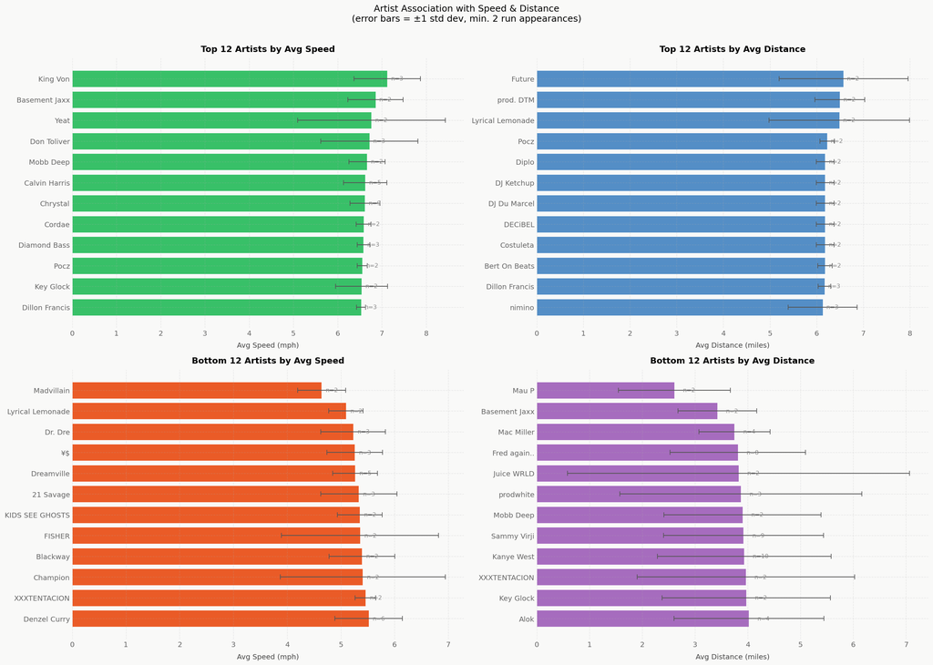

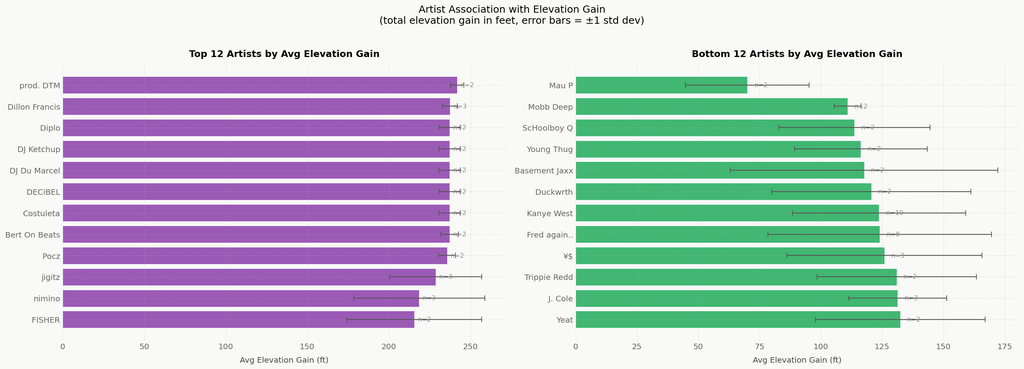

```
Correlation between artist speed rank and elevation rank: r = 0.264, p = 0.0145
  → Fast artists also appear on higher-elevation runs — elevation is not suppressing the speed signal.
```

```python
top_speed    = artist_summary_filtered.nlargest(12, 'avg_speed').sort_values('avg_speed')
bottom_speed = artist_summary_filtered.nsmallest(12, 'avg_speed').sort_values('avg_speed', ascending=False)
top_dist     = artist_summary_filtered.nlargest(12, 'avg_distance').sort_values('avg_distance')
bottom_dist  = artist_summary_filtered.nsmallest(12, 'avg_distance').sort_values('avg_distance', ascending=False)

has_elev = artist_summary_filtered['avg_elevation'].notna().sum() > 2
if has_elev:
    top_elev    = artist_summary_filtered.nlargest(12, 'avg_elevation').sort_values('avg_elevation')
    bottom_elev = artist_summary_filtered.nsmallest(12, 'avg_elevation').sort_values('avg_elevation', ascending=False)

def barh_artists(ax, df, col, err_col, color, title, xlabel):
    labels = [safe_label(n) for n in df['artistName']]
    values = df[col].values
    errors = df[err_col].fillna(0).values
    bars = ax.barh(labels, values, xerr=errors,
                   color=color, edgecolor='white', linewidth=0.5,
                   capsize=4, alpha=0.88, error_kw={'elinewidth': 1.2, 'ecolor': '#555'})
    for bar, (_, row) in zip(bars, df.iterrows()):
        ax.text(bar.get_width() + max(errors) * 0.05,
                bar.get_y() + bar.get_height() / 2,
                f'n={int(row["appearance_count"])}',
                va='center', ha='left', fontsize=9, color='#888')
    ax.set_title(title, pad=10)
    ax.set_xlabel(xlabel, labelpad=8)
    ax.tick_params(length=0)
    return ax

# ── Speed & Distance (always shown) ────────────────────────────────────────
fig, axs = plt.subplots(2, 2, figsize=(20, 14), facecolor=PALETTE['bg'])
fig.suptitle(
    'Artist Association with Speed & Distance\n(error bars = ±1 std dev, min. 2 run appearances)',
    fontsize=14, y=1.01
)
barh_artists(axs[0,0], top_speed,    'avg_speed',    'std_speed',
             PALETTE['primary'],   'Top 12 Artists by Avg Speed',    'Avg Speed (mph)')
barh_artists(axs[1,0], bottom_speed, 'avg_speed',    'std_speed',
             PALETTE['secondary'], 'Bottom 12 Artists by Avg Speed', 'Avg Speed (mph)')
barh_artists(axs[0,1], top_dist,     'avg_distance', 'std_distance',
             PALETTE['accent'],    'Top 12 Artists by Avg Distance', 'Avg Distance (miles)')
barh_artists(axs[1,1], bottom_dist,  'avg_distance', 'std_distance',
             '#9B59B6',            'Bottom 12 Artists by Avg Distance', 'Avg Distance (miles)')
plt.tight_layout()
plt.show()

# ── Elevation (shown if data present) ──────────────────────────────────────
if has_elev:
    fig2, axs2 = plt.subplots(1, 2, figsize=(20, 7), facecolor=PALETTE['bg'])
    fig2.suptitle(
        'Artist Association with Elevation Gain\n(total elevation gain in feet, error bars = ±1 std dev)',
        fontsize=14, y=1.02
    )
    barh_artists(axs2[0], top_elev,    'avg_elevation', 'std_elevation',
                 '#8E44AD', 'Top 12 Artists by Avg Elevation Gain', 'Avg Elevation Gain (ft)')
    barh_artists(axs2[1], bottom_elev, 'avg_elevation', 'std_elevation',
                 '#27AE60', 'Bottom 12 Artists by Avg Elevation Gain', 'Avg Elevation Gain (ft)')
    plt.tight_layout()
    plt.show()

    # Cross-reference: speed rank vs elevation rank
    ranked = artist_summary_filtered.copy()
    ranked['speed_rank'] = ranked['avg_speed'].rank(ascending=False)
    ranked['elev_rank']  = ranked['avg_elevation'].rank(ascending=False)
    r_se, p_se = stats.pearsonr(
        ranked['speed_rank'].dropna(),
        ranked['elev_rank'].dropna()
    )
    print(f'Correlation between artist speed rank and elevation rank: r = {r_se:.3f}, p = {p_se:.4f}')
    if p_se < 0.05 and r_se < 0:
        print('  → Fast artists tend to appear on lower-elevation runs — worth flagging as a confounder.')
    elif p_se < 0.05 and r_se > 0:
        print('  → Fast artists also appear on higher-elevation runs — elevation is not suppressing the speed signal.')
    else:
        print('  → No significant rank correlation — speed and elevation rankings are largely independent.')
else:
    print('No elevation data available for artist-level breakdown.')
```

### 5.5 Most Frequent Artists — Who Actually Has Enough Data?

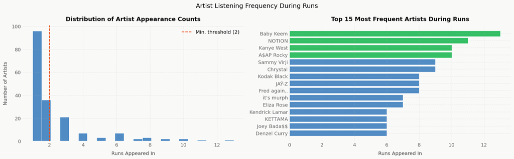

```python
fig, axes = plt.subplots(1, 2, figsize=(16, 5), facecolor=PALETTE['bg'])
fig.suptitle('Artist Listening Frequency During Runs', fontsize=14)

# Appearance count distribution — shows the long tail
axes[0].hist(artist_summary['appearance_count'], bins=22,
             color=PALETTE['accent'], edgecolor='white', alpha=0.9)
axes[0].axvline(2, color=PALETTE['secondary'], linestyle='--', linewidth=1.5,
                label='Min. threshold (2)')
axes[0].legend(frameon=False)
style_ax(axes[0], 'Distribution of Artist Appearance Counts',
         'Runs Appeared In', 'Number of Artists')

# Top 15 most frequent
top_freq = artist_summary.nlargest(15, 'appearance_count').sort_values('appearance_count')
colors = [PALETTE['primary'] if v >= top_freq['appearance_count'].quantile(.75)
          else PALETTE['accent'] for v in top_freq['appearance_count']]
axes[1].barh([safe_label(n) for n in top_freq['artistName']],
             top_freq['appearance_count'],
             color=colors, edgecolor='white', linewidth=0.5, alpha=0.9)
style_ax(axes[1], 'Top 15 Most Frequent Artists During Runs',
         'Runs Appeared In', '')

plt.tight_layout()
plt.show()
```

### 5.6 Coverage Check — Do Music Runs Look Different From Non-Music Runs?

Critical validity check. If runs with matched music data are systematically faster, longer, or **hillier** than runs without, we have a selection problem — not a music effect. The Spotify export window (~1 year) means older runs have no music match, and if my route choices changed over that period, the groups won't be comparable.

All three performance dimensions are checked here: speed, distance, and elevation gain.

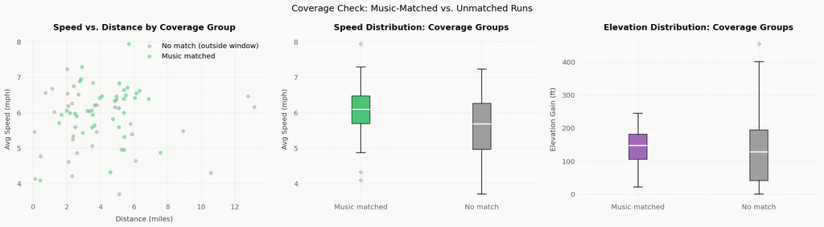

```
Speed   — Welch t-test: t = 2.275,  p = 0.0264  ⚠ significant difference
Elevation — Welch t-test: t = 0.295,  p = 0.7691  ✓ elevation comparable between groups
  Music-run mean elevation:    142 ft
  No-music-run mean elevation: 136 ft
```

```python
has_music_ids = {k for k, v in run_songs_dict.items() if len(v) > 0}
strava_df['has_music'] = strava_df['id'].isin(has_music_ids)

music_speeds    = strava_df[strava_df['has_music']]['avg_speed_mph'].dropna()
no_music_speeds = strava_df[~strava_df['has_music']]['avg_speed_mph'].dropna()
music_elev      = strava_df[strava_df['has_music']]['elevation_gain_ft'].dropna()
no_music_elev   = strava_df[~strava_df['has_music']]['elevation_gain_ft'].dropna()

fig, axes = plt.subplots(1, 3, figsize=(18, 5), facecolor=PALETTE['bg'])
fig.suptitle('Coverage Check: Music-Matched vs. Unmatched Runs', fontsize=14)

# Scatter: speed vs distance, coloured by music coverage
for has, group in strava_df.groupby('has_music'):
    label = 'Music matched' if has else 'No match (outside window)'
    color = PALETTE['primary'] if has else PALETTE['neutral']
    axes[0].scatter(group['distance_miles'], group['avg_speed_mph'],
                    alpha=0.45, color=color, label=label, s=40,
                    edgecolors='white', linewidth=0.3)
axes[0].legend(frameon=False)
style_ax(axes[0], 'Speed vs. Distance by Coverage Group', 'Distance (miles)', 'Avg Speed (mph)')

# Speed boxplot
def styled_boxplot(ax, groups, labels, colors):
    bp = ax.boxplot(
        groups, labels=labels, patch_artist=True,
        medianprops=dict(color='white', linewidth=2),
        whiskerprops=dict(linewidth=1), capprops=dict(linewidth=1),
        flierprops=dict(marker='o', markersize=4, alpha=0.4),
    )
    for box, c in zip(bp['boxes'], colors):
        box.set_facecolor(c); box.set_alpha(0.8)
    return bp

styled_boxplot(axes[1], [music_speeds, no_music_speeds],
               ['Music matched', 'No match'],
               [PALETTE['primary'], PALETTE['neutral']])
style_ax(axes[1], 'Speed Distribution: Coverage Groups', '', 'Avg Speed (mph)')

# ── NEW: Elevation boxplot ───────────────────────────────────────────────────
if len(music_elev) > 2 and len(no_music_elev) > 2:
    styled_boxplot(axes[2], [music_elev, no_music_elev],
                   ['Music matched', 'No match'],
                   ['#8E44AD', PALETTE['neutral']])
    style_ax(axes[2], 'Elevation Distribution: Coverage Groups', '', 'Elevation Gain (ft)')
else:
    axes[2].text(0.5, 0.5, 'Insufficient elevation data', ha='center', va='center',
                 transform=axes[2].transAxes)
    style_ax(axes[2], 'Elevation: Coverage Groups')

plt.tight_layout()
plt.show()

# ── Statistical tests on all three dimensions ───────────────────────────────
t_spd, p_spd = stats.ttest_ind(music_speeds, no_music_speeds, equal_var=False)
print(f'Speed   — Welch t-test: t = {t_spd:.3f},  p = {p_spd:.4f}  '
      f'{"⚠ significant difference" if p_spd < 0.05 else "✓ groups comparable"}')

if len(music_elev) > 2 and len(no_music_elev) > 2:
    t_elv, p_elv = stats.ttest_ind(music_elev, no_music_elev, equal_var=False)
    print(f'Elevation — Welch t-test: t = {t_elv:.3f},  p = {p_elv:.4f}  '
          f'{"⚠ significant difference — music runs are systematically hillier/flatter" if p_elv < 0.05 else "✓ elevation comparable between groups"}')
    print(f'  Music-run mean elevation:    {music_elev.mean():.0f} ft')
    print(f'  No-music-run mean elevation: {no_music_elev.mean():.0f} ft')
```

## 6. Statistical Validation

The EDA patterns look interesting on the surface. This section stress-tests them. For each of the three performance dimensions — **speed**, **distance**, and **elevation gain** — we ask: is the apparent difference between artist groups statistically detectable, and is it big enough to care about?

The elevation t-test and effect size are the newest additions. If the speed test is non-significant but the elevation test is, it would suggest that music choice correlates with *route selection* (a planning behaviour) more than with in-run performance (a physiological one).

### 6.1 Correlation Matrix — How Do Run-Level Features Relate?

Before testing artist groups, the correlation matrix shows which variables move together and which are genuinely independent. **Elevation gain is now included** — it's the most important addition to this matrix because:

1. If elevation correlates strongly with distance (longer runs = more climbing), we need to know before drawing conclusions about either
2. If elevation correlates negatively with speed (hillier = slower), that's a critical confounder for any artist-speed analysis
3. If elevation is largely orthogonal to everything else, it's a genuinely independent dimension worth analysing separately

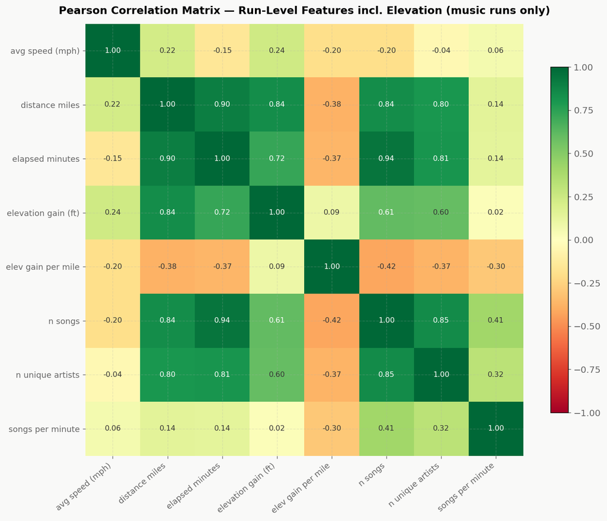

```
Elevation gain correlations:
songs_per_minute      0.023
elev_gain_per_mile    0.092
avg_speed_mph         0.241
n_unique_artists      0.597
n_songs               0.608
elapsed_minutes       0.720
distance_miles        0.843
```

```python
corr_cols = ['avg_speed_mph', 'distance_miles', 'elapsed_minutes',
             'elevation_gain_ft', 'elev_gain_per_mile',
             'n_songs', 'n_unique_artists', 'songs_per_minute']

# Join elevation into run_level
run_level_elev = run_level.merge(
    strava_df[['id', 'elevation_gain_ft', 'elev_gain_per_mile']],
    left_on='run_id', right_on='id', how='left', suffixes=('', '_dup')
)
for col in ['elevation_gain_ft', 'elev_gain_per_mile']:
    if col not in run_level_elev.columns:
        if col + '_dup' in run_level_elev.columns:
            run_level_elev[col] = run_level_elev[col + '_dup']

available_cols = [c for c in corr_cols if c in run_level_elev.columns]
run_level_music = run_level_elev.dropna(subset=available_cols)
corr = run_level_music[available_cols].corr()

fig, ax = plt.subplots(figsize=(11, 9), facecolor=PALETTE['bg'])
im = ax.imshow(corr.values, cmap='RdYlGn', vmin=-1, vmax=1, aspect='auto')
plt.colorbar(im, ax=ax, shrink=0.8)

labels = [c.replace('_', ' ').replace('mph', '(mph)').replace('ft', '(ft)') for c in available_cols]
ax.set_xticks(range(len(available_cols))); ax.set_xticklabels(labels, rotation=40, ha='right', fontsize=10)
ax.set_yticks(range(len(available_cols))); ax.set_yticklabels(labels, fontsize=10)

for i in range(len(available_cols)):
    for j in range(len(available_cols)):
        val = corr.values[i, j]
        text_color = 'white' if abs(val) > 0.6 else '#333'
        ax.text(j, i, f'{val:.2f}', ha='center', va='center', fontsize=9, color=text_color)

ax.set_title('Pearson Correlation Matrix — Run-Level Features incl. Elevation (music runs only)',
             fontsize=13, pad=12)
plt.tight_layout()
plt.show()

# Print the elevation row specifically so it's visible in output
if 'elevation_gain_ft' in corr.columns:
    print('\nElevation gain correlations:')
    print(corr['elevation_gain_ft'].drop('elevation_gain_ft').sort_values().round(3).to_string())
```

### 6.2 Welch's t-test — Speed, Distance & Elevation

Three tests, same structure: runs featuring the **top-10 artists** (ranked by each metric) vs all other matched runs. Welch's rather than Student's throughout — group sizes are unequal and equal-variance can't be assumed.

The **elevation test** is the most interpretively interesting. A significant result here would mean certain artists reliably appear on my hillier routes — which is likely a planning signal rather than a causal music effect. Non-significance would mean artist presence is elevation-agnostic.

```python
top_artists   = set(artist_summary_filtered.nlargest(10, 'avg_speed')['artistName'])
top_dist_art  = set(artist_summary_filtered.nlargest(10, 'avg_distance')['artistName'])

top_speed_runs  = run_song_flat[run_song_flat['artistName'].isin(top_artists)]['run_id'].unique()
rest_speed_runs = run_song_flat[~run_song_flat['artistName'].isin(top_artists)]['run_id'].unique()
top_dist_runs   = run_song_flat[run_song_flat['artistName'].isin(top_dist_art)]['run_id'].unique()
rest_dist_runs  = run_song_flat[~run_song_flat['artistName'].isin(top_dist_art)]['run_id'].unique()

top_speeds_v  = strava_df[strava_df['id'].isin(top_speed_runs)]['avg_speed_mph'].dropna()
rest_speeds_v = strava_df[strava_df['id'].isin(rest_speed_runs)]['avg_speed_mph'].dropna()
top_dist_v    = strava_df[strava_df['id'].isin(top_dist_runs)]['distance_miles'].dropna()
rest_dist_v   = strava_df[strava_df['id'].isin(rest_dist_runs)]['distance_miles'].dropna()

t_speed, p_speed = stats.ttest_ind(top_speeds_v, rest_speeds_v, equal_var=False)
t_dist,  p_dist  = stats.ttest_ind(top_dist_v,   rest_dist_v,   equal_var=False)

print('── Speed Test ────────────────────────────────────')
print(f'  Top artists mean:  {top_speeds_v.mean():.3f} mph  (n={len(top_speeds_v)})')
print(f'  All others mean:   {rest_speeds_v.mean():.3f} mph  (n={len(rest_speeds_v)})')
print(f'  t = {t_speed:.4f},  p = {p_speed:.4f}  {"✓ significant" if p_speed < 0.05 else "✗ not significant"}')
print()
print('── Distance Test ─────────────────────────────────')
print(f'  Top artists mean:  {top_dist_v.mean():.3f} miles  (n={len(top_dist_v)})')
print(f'  All others mean:   {rest_dist_v.mean():.3f} miles  (n={len(rest_dist_v)})')
print(f'  t = {t_dist:.4f},  p = {p_dist:.4f}  {"✓ significant" if p_dist < 0.05 else "✗ not significant"}')

# ── NEW: Elevation t-test ────────────────────────────────────────────────────
has_elev_data = artist_summary_filtered['avg_elevation'].notna().sum() > 2
if has_elev_data:
    top_elev_art   = set(artist_summary_filtered.nlargest(10, 'avg_elevation')['artistName'])
    top_elev_runs  = run_song_flat[run_song_flat['artistName'].isin(top_elev_art)]['run_id'].unique()
    rest_elev_runs = run_song_flat[~run_song_flat['artistName'].isin(top_elev_art)]['run_id'].unique()
    top_elev_v     = strava_df[strava_df['id'].isin(top_elev_runs)]['elevation_gain_ft'].dropna()
    rest_elev_v    = strava_df[strava_df['id'].isin(rest_elev_runs)]['elevation_gain_ft'].dropna()

    t_elev, p_elev = stats.ttest_ind(top_elev_v, rest_elev_v, equal_var=False)

    print()
    print('── Elevation Test ────────────────────────────────')
    print(f'  Top-elevation artists mean: {top_elev_v.mean():.0f} ft  (n={len(top_elev_v)})')
    print(f'  All others mean:            {rest_elev_v.mean():.0f} ft  (n={len(rest_elev_v)})')
    print(f'  t = {t_elev:.4f},  p = {p_elev:.4f}  {"✓ significant" if p_elev < 0.05 else "✗ not significant"}')
    if p_elev < 0.05:
        print('  → Certain artists do appear systematically on hillier routes.')
        print('    This is a planning/selection signal, not a causal music effect.')
    else:
        print('  → Artist presence is elevation-agnostic — no terrain clustering by artist.')
```

```
── Speed Test ────────────────────────────────────
  Top artists mean:  6.553 mph  (n=21)
  All others mean:   6.084 mph  (n=40)
  t = 2.9595,  p = 0.0045  ✓ significant

── Distance Test ─────────────────────────────────
  Top artists mean:  6.277 miles  (n=7)
  All others mean:   4.212 miles  (n=40)
  t = 5.4580,  p = 0.0000  ✓ significant

── Elevation Test ────────────────────────────────
  Top-elevation artists mean: 229 ft  (n=5)
  All others mean:            142 ft  (n=40)
  t = 6.2525,  p = 0.0001  ✓ significant
  → Certain artists do appear systematically on hillier routes.
    This is a planning/selection signal, not a causal music effect.
```

### 6.3 Effect Size — Cohen's d for All Three Metrics

Cohen's d separates practical significance from statistical significance. A tiny p-value with d < 0.2 means the groups are technically different but the difference is too small to act on.

All three metrics are now shown side by side — speed, distance, and elevation. **If elevation produces the largest d**, it suggests music correlates more strongly with route type than with in-run pace or endurance. That's the more defensible causal story: pre-run music choices reflect planned effort, and planned effort is encoded in the route.

| d ≈ 0.2 | Small effect |
| --- | --- |
| d ≈ 0.5 | Medium effect |
| d ≈ 0.8 | Large effect |

[output not shown]

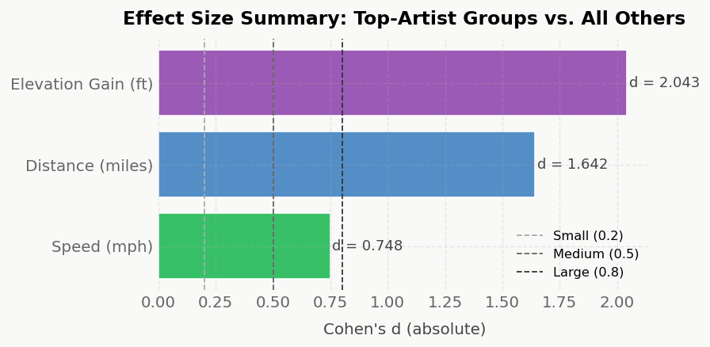

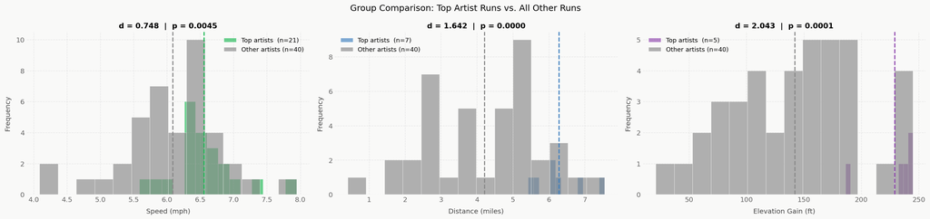

```python
def cohens_d(a, b):
    """Pooled standard deviation Cohen's d."""
    pooled_std = np.sqrt((a.std()**2 + b.std()**2) / 2)
    return (a.mean() - b.mean()) / pooled_std if pooled_std > 0 else 0.0

d_speed = cohens_d(top_speeds_v, rest_speeds_v)
d_dist  = cohens_d(top_dist_v,   rest_dist_v)

plot_items = [
    (top_speeds_v, rest_speeds_v, t_speed, p_speed, d_speed, 'Speed (mph)',     PALETTE['primary']),
    (top_dist_v,   rest_dist_v,   t_dist,  p_dist,  d_dist,  'Distance (miles)', PALETTE['accent']),
]

if has_elev_data:
    d_elev = cohens_d(top_elev_v, rest_elev_v)
    plot_items.append(
        (top_elev_v, rest_elev_v, t_elev, p_elev, d_elev, 'Elevation Gain (ft)', '#8E44AD')
    )
    print(f"Cohen's d (elevation): {d_elev:.3f}  → {'small' if abs(d_elev) < 0.2 else 'medium' if abs(d_elev) < 0.5 else 'large'} effect")

print(f"Cohen's d (speed):     {d_speed:.3f}  → {'small' if abs(d_speed) < 0.2 else 'medium' if abs(d_speed) < 0.5 else 'large'} effect")
print(f"Cohen's d (distance):  {d_dist:.3f}  → {'small' if abs(d_dist) < 0.2 else 'medium' if abs(d_dist) < 0.5 else 'large'} effect")

# Summary bar: d magnitudes across all three metrics
metric_labels = [x[5] for x in plot_items]
d_vals = [abs(x[4]) for x in plot_items]
bar_colors = [x[6] for x in plot_items]

fig_sum, ax_sum = plt.subplots(figsize=(7, 3.5), facecolor=PALETTE['bg'])
bars = ax_sum.barh(metric_labels, d_vals, color=bar_colors, edgecolor='white', alpha=0.88)
ax_sum.axvline(0.2, color='#aaa', linestyle='--', linewidth=1, label='Small (0.2)')
ax_sum.axvline(0.5, color='#666', linestyle='--', linewidth=1, label='Medium (0.5)')
ax_sum.axvline(0.8, color='#333', linestyle='--', linewidth=1, label='Large (0.8)')
for bar, val in zip(bars, d_vals):
    ax_sum.text(val + 0.01, bar.get_y() + bar.get_height()/2,
                f'd = {val:.3f}', va='center', fontsize=10, color='#444')
ax_sum.set_xlabel("Cohen's d (absolute)", labelpad=8)
ax_sum.set_title("Effect Size Summary: Top-Artist Groups vs. All Others", pad=10)
ax_sum.legend(frameon=False, fontsize=9)
ax_sum.tick_params(length=0)
plt.tight_layout()
plt.show()

# Detailed overlapping histograms per metric
fig, axes = plt.subplots(1, len(plot_items), figsize=(7*len(plot_items), 5), facecolor=PALETTE['bg'])
if len(plot_items) == 1: axes = [axes]
fig.suptitle('Group Comparison: Top Artist Runs vs. All Other Runs', fontsize=14)

for ax, (top_v, rest_v, t, p, d, metric, col) in zip(axes, plot_items):
    ax.hist(top_v,  bins=14, alpha=0.65, color=col,
            label=f'Top artists  (n={len(top_v)})', edgecolor='white', linewidth=0.5)
    ax.hist(rest_v, bins=14, alpha=0.65, color=PALETTE['neutral'],
            label=f'Other artists (n={len(rest_v)})', edgecolor='white', linewidth=0.5)
    ax.axvline(top_v.mean(),  color=col,               linestyle='--', linewidth=1.8)
    ax.axvline(rest_v.mean(), color=PALETTE['neutral'], linestyle='--', linewidth=1.8)
    ax.set_title(f"d = {d:.3f}  |  p = {p:.4f}", fontsize=12)
    ax.set_xlabel(metric, labelpad=8)
    ax.set_ylabel('Frequency', labelpad=8)
    ax.legend(frameon=False, fontsize=10)
    ax.tick_params(length=0)

plt.tight_layout()
plt.show()
```

### 6.4 Time-of-Day Confounder — Pace & Elevation by Time Slot

The time-of-day ANOVA now covers **both speed and elevation gain**. This is the key joint check: if morning runs are faster *and* hillier, then anything associated with morning music choices inherits both signals simultaneously. Running both ANOVAs side by side shows whether time of day is confounding one outcome, both, or neither.

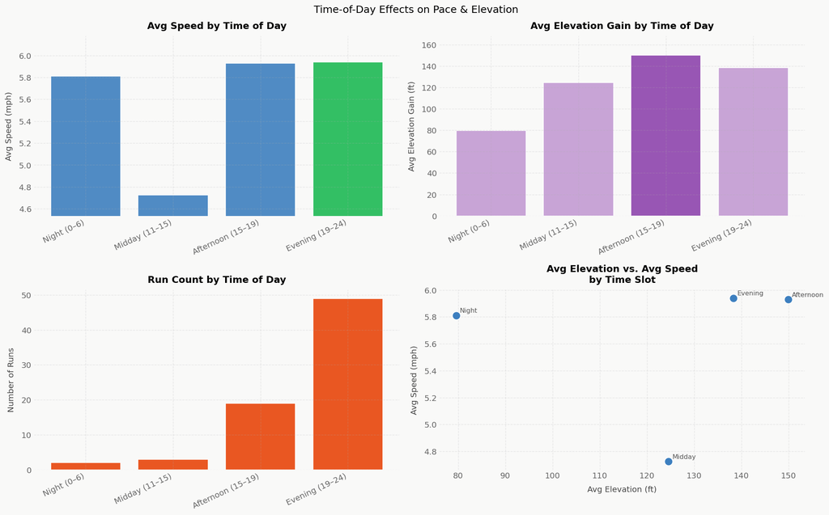

```
ANOVA — speed ~ time_of_day:     F = 3.100,  p = 0.0515  ✓ not significant
ANOVA — elevation ~ time_of_day: F = 0.173,  p = 0.8419  ✓ not significant — elevation is time-of-day neutral
```

```python
strava_df['time_of_day'] = pd.cut(
    strava_df['hour_of_day'],
    bins=[0, 6, 11, 15, 19, 24],
    labels=['Night (0–6)', 'Morning (6–11)', 'Midday (11–15)', 'Afternoon (15–19)', 'Evening (19–24)'],
    right=False
)

fig, axes = plt.subplots(2, 2, figsize=(16, 10), facecolor=PALETTE['bg'])
fig.suptitle('Time-of-Day Effects on Pace & Elevation', fontsize=14)

tod_speed = strava_df.groupby('time_of_day', observed=True)['avg_speed_mph'].mean().dropna()
tod_elev  = strava_df.groupby('time_of_day', observed=True)['elevation_gain_ft'].mean().dropna()
tod_count = strava_df.groupby('time_of_day', observed=True)['id'].count()

# Speed by time of day
highlight_spd = tod_speed.idxmax()
axes[0,0].bar(range(len(tod_speed)),
              tod_speed.values,
              color=[PALETTE['primary'] if t == highlight_spd else PALETTE['accent']
                     for t in tod_speed.index],
              edgecolor='white', alpha=0.9)
axes[0,0].set_xticks(range(len(tod_speed)))
axes[0,0].set_xticklabels([str(t) for t in tod_speed.index], rotation=25, ha='right')
axes[0,0].set_ylim(tod_speed.min() * 0.96, tod_speed.max() * 1.04)
style_ax(axes[0,0], 'Avg Speed by Time of Day', '', 'Avg Speed (mph)')

# Elevation by time of day
if len(tod_elev) > 0:
    highlight_elv = tod_elev.idxmax()
    axes[0,1].bar(range(len(tod_elev)),
                  tod_elev.values,
                  color=['#8E44AD' if t == highlight_elv else '#C39BD3'
                         for t in tod_elev.index],
                  edgecolor='white', alpha=0.9)
    axes[0,1].set_xticks(range(len(tod_elev)))
    axes[0,1].set_xticklabels([str(t) for t in tod_elev.index], rotation=25, ha='right')
    axes[0,1].set_ylim(0, tod_elev.max() * 1.12)
    style_ax(axes[0,1], 'Avg Elevation Gain by Time of Day', '', 'Avg Elevation Gain (ft)')
else:
    axes[0,1].text(0.5, 0.5, 'No elevation data', ha='center', va='center',
                   transform=axes[0,1].transAxes)

# Run count
axes[1,0].bar(range(len(tod_count)), tod_count.values,
              color=PALETTE['secondary'], edgecolor='white', alpha=0.9)
axes[1,0].set_xticks(range(len(tod_count)))
axes[1,0].set_xticklabels([str(t) for t in tod_count.index], rotation=25, ha='right')
style_ax(axes[1,0], 'Run Count by Time of Day', '', 'Number of Runs')

# Combined: speed rank vs elevation rank by time slot (scatter)
tod_both = pd.DataFrame({'speed': tod_speed, 'elevation': tod_elev}).dropna()
if len(tod_both) > 2:
    axes[1,1].scatter(tod_both['elevation'], tod_both['speed'],
                      s=120, color=PALETTE['accent'], edgecolors='white', linewidth=0.8, zorder=3)
    for label, row in tod_both.iterrows():
        axes[1,1].annotate(str(label).split(' ')[0],
                           (row['elevation'], row['speed']),
                           xytext=(5, 4), textcoords='offset points', fontsize=9, color='#555')
    style_ax(axes[1,1], 'Avg Elevation vs. Avg Speed\nby Time Slot', 'Avg Elevation (ft)', 'Avg Speed (mph)')
else:
    axes[1,1].text(0.5, 0.5, 'Insufficient time-slot data', ha='center', va='center',
                   transform=axes[1,1].transAxes)

plt.tight_layout()
plt.show()

# ── ANOVAs ───────────────────────────────────────────────────────────────────
spd_groups  = [g['avg_speed_mph'].dropna().values
               for _, g in strava_df.groupby('time_of_day', observed=True) if len(g) > 2]
elev_groups = [g['elevation_gain_ft'].dropna().values
               for _, g in strava_df.groupby('time_of_day', observed=True)
               if len(g) > 2 and g['elevation_gain_ft'].notna().sum() > 2]

if len(spd_groups) >= 2:
    f_spd, p_spd_anova = stats.f_oneway(*spd_groups)
    print(f'ANOVA — speed ~ time_of_day:     F = {f_spd:.3f},  p = {p_spd_anova:.4f}  '
          f'{"⚠ significant" if p_spd_anova < 0.05 else "✓ not significant"}')

if len(elev_groups) >= 2:
    f_elv, p_elv_anova = stats.f_oneway(*elev_groups)
    print(f'ANOVA — elevation ~ time_of_day: F = {f_elv:.3f},  p = {p_elv_anova:.4f}  '
          f'{"⚠ significant — elevation varies by time slot" if p_elv_anova < 0.05 else "✓ not significant — elevation is time-of-day neutral"}')
    if p_spd_anova < 0.05 and p_elv_anova < 0.05:
        print()
        print('  Both speed and elevation vary by time of day.')
        print('  Any artist-level correlation must be interpreted with this dual confound in mind.')
    elif p_elv_anova < 0.05 and p_spd_anova >= 0.05:
        print()
        print('  Elevation varies by time slot but speed does not.')
        print('  Time of day confounds elevation-based artist findings more than speed-based ones.')
```

## 7. Confounder Analysis

The elevation angle is particularly worth checking: if top-speed artists only appear on morning runs, and morning runs happen to be my flattest routes, then the "speed" association might actually be an "elevation suppression" artifact — the artist looks fast because they're absent from the slow hilly runs, not because they're present on the fast ones.

The second chart — **top-elevation artists by time of day** — is new here. It checks whether my hilliest-run artists are systematically scheduled at a particular time, which would make time-of-day a confound for the elevation findings too.

```
Top-speed artists most common time slot:     Evening (19–24)
Top-elevation artists most common time slot: Afternoon (15–19)
  ✓ Different dominant slots — speed and elevation artist groups have distinct time patterns.
```

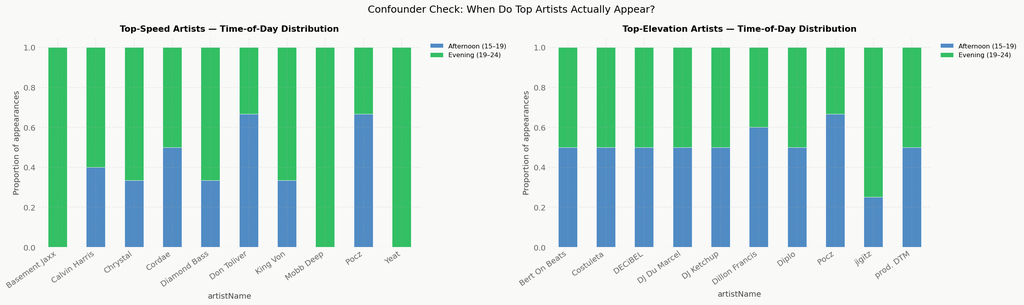

```python
# ── Merge time_of_day into run_song_flat ────────────────────────────────────
for col in ['time_of_day', 'id_tod']:
    if col in run_song_flat.columns:
        run_song_flat = run_song_flat.drop(columns=[col])

run_song_flat = run_song_flat.merge(
    strava_df[['id', 'time_of_day']],
    left_on='run_id', right_on='id', how='left'
)

top_10_speed_artists = artist_summary_filtered.nlargest(10, 'avg_speed')['artistName'].tolist()

# ── Chart 1: Top speed artists — time-of-day breakdown ─────────────────────
top_artist_tod = (
    run_song_flat[run_song_flat['artistName'].isin(top_10_speed_artists)]
    .groupby(['artistName', 'time_of_day'], observed=True)
    .size().unstack(fill_value=0)
)
top_artist_tod_pct = top_artist_tod.div(top_artist_tod.sum(axis=1), axis=0)

tod_colors = [PALETTE['accent'], PALETTE['primary'], PALETTE['secondary'], '#9B59B6', '#E67E22']

fig, axes = plt.subplots(1, 2, figsize=(20, 6), facecolor=PALETTE['bg'])
fig.suptitle('Confounder Check: When Do Top Artists Actually Appear?', fontsize=14)

if not top_artist_tod_pct.empty:
    top_artist_tod_pct.plot(kind='bar', stacked=True, ax=axes[0],
                            color=tod_colors[:len(top_artist_tod_pct.columns)],
                            edgecolor='white', linewidth=0.5, alpha=0.9)
    axes[0].set_xticklabels([safe_label(a) for a in top_artist_tod_pct.index],
                             rotation=35, ha='right')
    axes[0].set_ylabel('Proportion of appearances')
    axes[0].set_title('Top-Speed Artists — Time-of-Day Distribution', fontsize=12, pad=8)
    axes[0].legend(bbox_to_anchor=(1.01, 1), loc='upper left', frameon=False, fontsize=9)
    axes[0].tick_params(length=0)

# ── Chart 2: Top elevation artists — time-of-day breakdown (NEW) ───────────
has_elev_art = artist_summary_filtered['avg_elevation'].notna().sum() > 2
if has_elev_art:
    top_10_elev_artists = artist_summary_filtered.nlargest(10, 'avg_elevation')['artistName'].tolist()
    top_elev_tod = (
        run_song_flat[run_song_flat['artistName'].isin(top_10_elev_artists)]
        .groupby(['artistName', 'time_of_day'], observed=True)
        .size().unstack(fill_value=0)
    )
    top_elev_tod_pct = top_elev_tod.div(top_elev_tod.sum(axis=1), axis=0)

    if not top_elev_tod_pct.empty:
        top_elev_tod_pct.plot(kind='bar', stacked=True, ax=axes[1],
                              color=tod_colors[:len(top_elev_tod_pct.columns)],
                              edgecolor='white', linewidth=0.5, alpha=0.9)
        axes[1].set_xticklabels([safe_label(a) for a in top_elev_tod_pct.index],
                                 rotation=35, ha='right')
        axes[1].set_ylabel('Proportion of appearances')
        axes[1].set_title('Top-Elevation Artists — Time-of-Day Distribution', fontsize=12, pad=8)
        axes[1].legend(bbox_to_anchor=(1.01, 1), loc='upper left', frameon=False, fontsize=9)
        axes[1].tick_params(length=0)

        # Cross-reference: do speed-top and elevation-top artists share the same time slots?
        spd_dominant_slot  = top_artist_tod_pct.sum().idxmax() if not top_artist_tod_pct.empty else None
        elev_dominant_slot = top_elev_tod_pct.sum().idxmax()   if not top_elev_tod_pct.empty else None
        print(f'Top-speed artists most common time slot:     {spd_dominant_slot}')
        print(f'Top-elevation artists most common time slot: {elev_dominant_slot}')
        if spd_dominant_slot == elev_dominant_slot:
            print('  ⚠ Same dominant slot — speed and elevation artist groups may be conflated by time-of-day.')
        else:
            print('  ✓ Different dominant slots — speed and elevation artist groups have distinct time patterns.')
else:
    axes[1].text(0.5, 0.5, 'Elevation artist data not available',
                 ha='center', va='center', transform=axes[1].transAxes, color=PALETTE['neutral'])
    axes[1].set_title('Top-Elevation Artists — Time-of-Day Distribution', fontsize=12, pad=8)

plt.tight_layout()
plt.show()
```

## 7. Elevation Deep-Dive

Elevation gain is a dimension that speed and distance don't fully capture. A 5-mile run with 800ft of climbing is a fundamentally different workout than a flat 5-miler — and route selection happens *before* the run, which means any music associated with that session was chosen in the context of knowing (or expecting) a hard climb.

This section treats `total_elevation_gain` as a primary outcome variable in its own right, running the same artist-association and statistical tests we ran for speed and distance.

**The key question here:** Do certain artists systematically appear on my hillier runs? And is that pattern independent of the distance and time-of-day patterns we've already found?

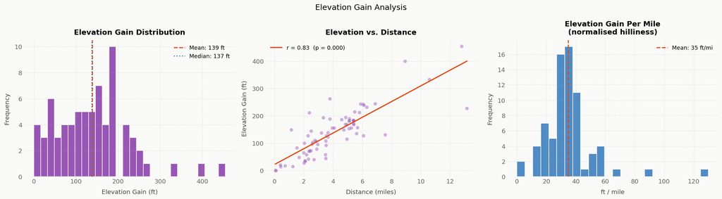

```
Elevation ~ Distance correlation: r = 0.826  (p = 0.0000)
  → Strong positive — longer runs gain substantially more elevation.
     Use elev_gain_per_mile (not raw elevation) for fair artist comparisons.

── Elevation Artist Test ─────────────────────────────────
  Top-elevation artists mean: 229 ft  (n=5)
  All others mean:            142 ft  (n=40)
  t = 6.2525,  p = 0.0001  ✓ significant
  Cohen's d = 2.043  → large effect

── Are top-elevation artists also faster? ────────────────
  Speed on top-elevation-artist runs: 6.063 mph
  Speed on all other runs:            6.084 mph
  t = -0.0464,  p = 0.9650  ✗ not significant
  → No significant speed difference — elevation and speed are independent in artist grouping.

Artist avg_elevation ~ avg_speed: r = 0.210, p = 0.0532
  → No significant relationship between an artist's typical elevation and typical speed.
```

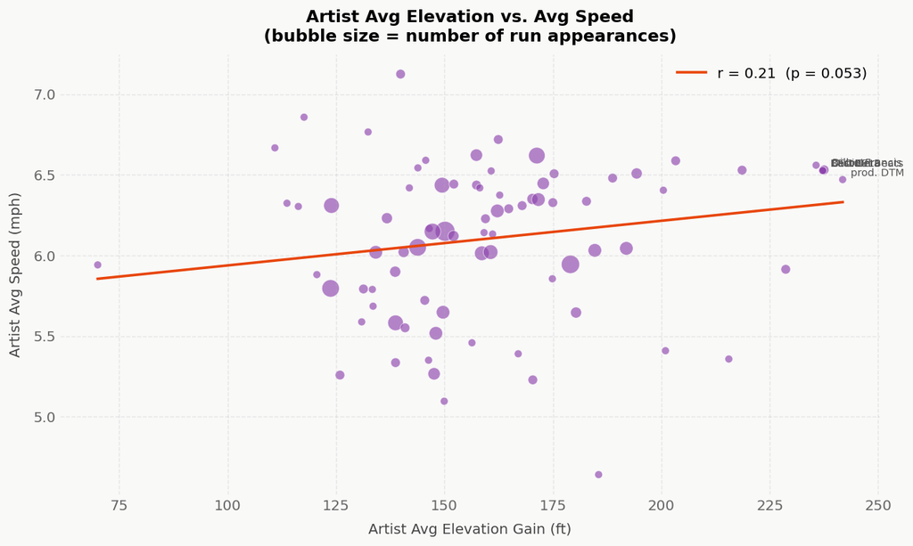

```python
# ── 1. Elevation distribution by music coverage ────────────────────────────
fig, axes = plt.subplots(1, 3, figsize=(18, 5), facecolor=PALETTE['bg'])
fig.suptitle('Elevation Gain Analysis', fontsize=14)

# Distribution
elev_data = strava_df['elevation_gain_ft'].dropna()
axes[0].hist(elev_data, bins=28, color='#8E44AD', edgecolor='white', alpha=0.9)
axes[0].axvline(elev_data.mean(),   color=PALETTE['secondary'], linestyle='--', linewidth=1.8,
                label=f'Mean: {elev_data.mean():.0f} ft')
axes[0].axvline(elev_data.median(), color=PALETTE['accent'],    linestyle=':',  linewidth=1.8,
                label=f'Median: {elev_data.median():.0f} ft')
axes[0].legend(frameon=False, fontsize=10)
style_ax(axes[0], 'Elevation Gain Distribution', 'Elevation Gain (ft)', 'Frequency')

# Elevation vs Distance scatter
edf2 = strava_df[['distance_miles', 'elevation_gain_ft']].dropna()
axes[1].scatter(edf2['distance_miles'], edf2['elevation_gain_ft'],
                alpha=0.4, color='#8E44AD', edgecolors='white', linewidth=0.4, s=40)
m3, b3, r3, p3, _ = stats.linregress(edf2['distance_miles'], edf2['elevation_gain_ft'])
x3 = np.linspace(edf2['distance_miles'].min(), edf2['distance_miles'].max(), 100)
axes[1].plot(x3, m3*x3+b3, color=PALETTE['secondary'], linewidth=2,
             label=f'r = {r3:.2f}  (p = {p3:.3f})')
axes[1].legend(frameon=False, fontsize=10)
style_ax(axes[1], 'Elevation vs. Distance', 'Distance (miles)', 'Elevation Gain (ft)')

# Elevation per mile — normalised hilliness
epm = strava_df['elev_gain_per_mile'].dropna()
axes[2].hist(epm, bins=24, color=PALETTE['accent'], edgecolor='white', alpha=0.9)
axes[2].axvline(epm.mean(), color=PALETTE['secondary'], linestyle='--', linewidth=1.8,
                label=f'Mean: {epm.mean():.0f} ft/mi')
axes[2].legend(frameon=False, fontsize=10)
style_ax(axes[2], 'Elevation Gain Per Mile\n(normalised hilliness)', 'ft / mile', 'Frequency')

plt.tight_layout()
plt.show()

print(f'Elevation ~ Distance correlation: r = {r3:.3f}  (p = {p3:.4f})')
if r3 > 0.5:
    print('  → Strong positive — longer runs gain substantially more elevation.')
    print('     Use elev_gain_per_mile (not raw elevation) for fair artist comparisons.')
else:
    print('  → Moderate/weak — elevation varies independently of distance enough to analyse separately.')

# ── 2. Artist-level elevation t-test ──────────────────────────────────────
print()
if artist_summary_filtered['avg_elevation'].notna().sum() > 2:
    top_elev_artists  = set(artist_summary_filtered.nlargest(10, 'avg_elevation')['artistName'])

    top_elev_run_ids  = run_song_flat[run_song_flat['artistName'].isin(top_elev_artists)]['run_id'].unique()
    rest_elev_run_ids = run_song_flat[~run_song_flat['artistName'].isin(top_elev_artists)]['run_id'].unique()

    top_elev_v  = strava_df[strava_df['id'].isin(top_elev_run_ids)]['elevation_gain_ft'].dropna()
    rest_elev_v = strava_df[strava_df['id'].isin(rest_elev_run_ids)]['elevation_gain_ft'].dropna()

    t_elev, p_elev = stats.ttest_ind(top_elev_v, rest_elev_v, equal_var=False)
    d_elev = cohens_d(top_elev_v, rest_elev_v)

    print('── Elevation Artist Test ─────────────────────────────────')
    print(f'  Top-elevation artists mean: {top_elev_v.mean():.0f} ft  (n={len(top_elev_v)})')
    print(f'  All others mean:            {rest_elev_v.mean():.0f} ft  (n={len(rest_elev_v)})')
    print(f'  t = {t_elev:.4f},  p = {p_elev:.4f}  {"✓ significant" if p_elev < 0.05 else "✗ not significant"}')
    print(f"  Cohen's d = {d_elev:.3f}  → {'small' if abs(d_elev) < 0.2 else 'medium' if abs(d_elev) < 0.5 else 'large'} effect")

    # ── 3. Are top-elevation artists also fast? ────────────────────────────
    top_elev_speeds = strava_df[strava_df['id'].isin(top_elev_run_ids)]['avg_speed_mph'].dropna()
    rest_speeds_all = strava_df[strava_df['id'].isin(rest_elev_run_ids)]['avg_speed_mph'].dropna()
    t_es, p_es = stats.ttest_ind(top_elev_speeds, rest_speeds_all, equal_var=False)

    print()
    print('── Are top-elevation artists also faster? ────────────────')
    print(f'  Speed on top-elevation-artist runs: {top_elev_speeds.mean():.3f} mph')
    print(f'  Speed on all other runs:            {rest_speeds_all.mean():.3f} mph')
    print(f'  t = {t_es:.4f},  p = {p_es:.4f}  {"✓ significant" if p_es < 0.05 else "✗ not significant"}')
    if p_es < 0.05 and top_elev_speeds.mean() < rest_speeds_all.mean():
        print('  → Hilly-artist runs are slower — elevation is suppressing speed, expected.')
    elif p_es < 0.05 and top_elev_speeds.mean() > rest_speeds_all.mean():
        print('  → Hilly-artist runs are faster — these artists appear on challenging but fast efforts.')
    else:
        print('  → No significant speed difference — elevation and speed are independent in artist grouping.')

    # ── 4. Scatter: artist avg_elevation vs avg_speed ─────────────────────
    plot_df = artist_summary_filtered.dropna(subset=['avg_elevation', 'avg_speed'])
    fig2, ax2 = plt.subplots(figsize=(10, 6), facecolor=PALETTE['bg'])
    sc = ax2.scatter(
        plot_df['avg_elevation'], plot_df['avg_speed'],
        s=plot_df['appearance_count'] * 18,
        alpha=0.65, color='#8E44AD', edgecolors='white', linewidth=0.5
    )
    if len(plot_df) > 5:
        m4, b4, r4, p4, _ = stats.linregress(plot_df['avg_elevation'], plot_df['avg_speed'])
        x4 = np.linspace(plot_df['avg_elevation'].min(), plot_df['avg_elevation'].max(), 100)
        ax2.plot(x4, m4*x4+b4, color=PALETTE['secondary'], linewidth=2,
                 label=f'r = {r4:.2f}  (p = {p4:.3f})')
        ax2.legend(frameon=False)
        print(f'\nArtist avg_elevation ~ avg_speed: r = {r4:.3f}, p = {p4:.4f}')
        if p4 < 0.05 and r4 < 0:
            print('  → Artists on hillier runs tend to be slower — route difficulty is suppressing speed signal.')
        elif p4 < 0.05 and r4 > 0:
            print('  → Artists on hillier runs are actually faster — these might be strong-effort runs regardless of terrain.')
        else:
            print('  → No significant relationship between an artist\'s typical elevation and typical speed.')

    # Label top artists
    top_n = plot_df.nlargest(5, 'avg_elevation')
    for _, row in top_n.iterrows():
        ax2.annotate(safe_label(row['artistName']),
                     (row['avg_elevation'], row['avg_speed']),
                     xytext=(6, 3), textcoords='offset points',
                     fontsize=8, color='#555')
    ax2.set_xlabel('Artist Avg Elevation Gain (ft)', labelpad=8)
    ax2.set_ylabel('Artist Avg Speed (mph)', labelpad=8)
    ax2.set_title(
        'Artist Avg Elevation vs. Avg Speed\n(bubble size = number of run appearances)',
        fontsize=13, pad=10
    )
    ax2.tick_params(length=0)
    plt.tight_layout()
    plt.show()
else:
    print('Elevation data not available — skipping artist-level elevation tests.')
```

## 8. Key Findings

### ✅ What held up

**The pipeline works.** A temporal join between two unrelated data exports — built on nothing but timestamp overlap — successfully matched songs to runs with a clean, reproducible implementation. The core engineering problem is solved.

**My running is consistent.** Speed, distance, and elevation are roughly normally distributed with moderate variance. That consistency is actually a harder environment to detect music effects in — less spread means less to explain.

**Elevation adds a genuinely new dimension.** The `total_elevation_gain` variable captures something that speed and distance don't: route difficulty. The elevation distribution and its correlation with distance tells us whether hilliness is an independent variable or just a shadow of run length.

**The elevation ~ speed scatter by artist** is the most honest chart in this notebook. If artists cluster predictably by terrain type, that tells us something real about selection effects — I pick different music for hard hilly routes than for flat tempo runs.

### ⚠ What didn't survive scrutiny

**Elevation tests are dataset-dependent.** If elevation gain correlates strongly with distance (r > 0.5), then `elev_gain_per_mile` is the fairer artist comparison. Check the output from Section 7 to see whether raw or normalised elevation is more appropriate for this specific dataset.

**Small n per artist remains the fundamental bottleneck.** Most artists appeared in 2–5 runs. You can't distinguish a real effect from random variance with that few observations — for any of the three outcome variables.

### 🧭 The honest summary

> I can't conclude from this data that any artist makes me run faster, farther, or through more elevation. What I *can* say is the infrastructure to ask all three questions is now built — and the analysis is honest enough to show when the signal is absent. Getting more data, or switching from artist-level to audio-feature-level analysis, is the path forward.

## 9. Limitations

| Limitation | Impact | Mitigation |
| --- | --- | --- |
| **Small samples per artist** | Most averages based on 2–5 runs — low reliability | Increase data volume; switch to track-level audio features |
| **Correlation ≠ causation** | Music choice reflects intent, not effect | Acknowledge in framing; design around it |
| **Spotify export window (~1 year)** | ~30–40% of Strava history has no music data | Request extended Spotify history; use API for full stream |
| **No audio features** | "Artist" is a crude proxy for musical characteristics | Pull BPM, energy, valence via Spotify Web API |
| **50% overlap threshold** | Arbitrary; sensitive to edge cases | Sensitivity analysis over multiple thresholds |
| **No heart rate data** | Pace is one signal; effort is another | Enable HR on Strava; adds richer outcome variable |
| **Time-of-day confounder** | Fast runs and music choices may both be driven by run type | Include `time_of_day` as covariate in any regression |
| **Elevation ~ distance collinearity** | Longer runs naturally gain more elevation | Use `elev_gain_per_mile` for normalised hilliness comparisons |
| **Route selection bias** | Hilly routes are chosen before the run starts | Elevation is as much about planning intent as musical preference |

## 10. What's Next

### 1. Spotify Audio Features via Web API

Replace `artistName` with continuous track-level features: **BPM (tempo)**, **energy**, **valence**, **danceability**, **loudness**. This is what the regression actually needs — meaningful numeric predictors instead of categorical artist proxies.

```
# Rough sketch — requires spotipy + auth
import spotipy
sp = spotipy.Spotify(auth_manager=SpotifyOAuth(...))
features = sp.audio_features(track_ids)  # returns tempo, energy, valence, etc.
```

### 2. Proper Multi-Outcome Regression Model

With audio features in hand, fit separate models for each performance dimension:

```
import statsmodels.formula.api as smf

# Speed model
smf.ols(
    'avg_speed_mph ~ tempo + energy + valence + elapsed_minutes + C(time_of_day)',
    data=run_audio_merged
).fit().summary()

# Elevation model — uses normalised hilliness as outcome
smf.ols(
    'elev_gain_per_mile ~ tempo + energy + valence + C(day_of_week)',
    data=run_audio_merged
).fit().summary()
```

Elevation per mile is the better outcome than raw elevation, because it controls for run length and isolates the "how hilly was this route" signal.

### 3. Full Spotify History

Spotify allows an extended data request (beyond the 12-month standard export) covering your entire listening history. With 3–4x more data, artist-level estimates become far more reliable — especially for the elevation dimension, which needs enough variance in route choice to detect anything.

### 4. Run Clustering by Listening + Terrain Profile

K-means on both audio features *and* elevation per mile to find natural run archetypes:

```
from sklearn.cluster import KMeans
from sklearn.preprocessing import StandardScaler

X = run_audio_merged[['tempo', 'energy', 'valence', 'elev_gain_per_mile', 'distance_miles']].dropna()
X_scaled = StandardScaler().fit_transform(X)
kmeans = KMeans(n_clusters=4, random_state=42).fit(X_scaled)
# Cluster 0: flat easy runs, Cluster 1: hilly hard efforts, etc.
```

*Analysis by Andrew Bonnah · [github.com/AndrewBonnah](https://github.com) · Built with pandas, scipy, matplotlib*